# Risk Factor Analysis

## Outcome Variable

**Outcome Variable:** ever_swasted

## Predictor Variables

**Intervention Variable:** meducyrs

**Adjustment Set:**

- arm
- W_mage
- feducyrs
- hhwealth_quart
- W_mhtcm
- W_mwtkg
- W_mbmi
- W_gagebrth
- W_birthwt
- W_birthlen
- single
- impsan
- delta_W_mage
- delta_feducyrs
- delta_hhwealth_quart
- delta_W_mhtcm
- delta_W_mwtkg
- delta_W_mbmi
- delta_W_gagebrth
- delta_W_birthwt
- delta_W_birthlen
- delta_single
- delta_impsan

## Stratifying Variables

The analysis was stratified on these variable(s):

- agecat
- studyid
- country

## Data Summary

| agecat | studyid | country | meducyrs | ever_swasted | n_cell | n |
| --- | --- | --- | --- | --- | --- | --- |
| 0-24 months | CMC-V-BCS-2002 | INDIA | High | 0 | 122 | 373 |
| 0-24 months | CMC-V-BCS-2002 | INDIA | High | 1 | 36 | 373 |
| 0-24 months | CMC-V-BCS-2002 | INDIA | Low | 0 | 78 | 373 |
| 0-24 months | CMC-V-BCS-2002 | INDIA | Low | 1 | 28 | 373 |
| 0-24 months | CMC-V-BCS-2002 | INDIA | Medium | 0 | 81 | 373 |
| 0-24 months | CMC-V-BCS-2002 | INDIA | Medium | 1 | 28 | 373 |
| 0-24 months | COHORTS | GUATEMALA | High | 0 | 259 | 1322 |
| 0-24 months | COHORTS | GUATEMALA | High | 1 | 21 | 1322 |
| 0-24 months | COHORTS | GUATEMALA | Low | 0 | 589 | 1322 |
| 0-24 months | COHORTS | GUATEMALA | Low | 1 | 38 | 1322 |
| 0-24 months | COHORTS | GUATEMALA | Medium | 0 | 380 | 1322 |
| 0-24 months | COHORTS | GUATEMALA | Medium | 1 | 35 | 1322 |
| 0-24 months | COHORTS | INDIA | High | 0 | 749 | 5844 |
| 0-24 months | COHORTS | INDIA | High | 1 | 44 | 5844 |
| 0-24 months | COHORTS | INDIA | Low | 0 | 1679 | 5844 |
| 0-24 months | COHORTS | INDIA | Low | 1 | 272 | 5844 |
| 0-24 months | COHORTS | INDIA | Medium | 0 | 2814 | 5844 |
| 0-24 months | COHORTS | INDIA | Medium | 1 | 286 | 5844 |
| 0-24 months | COHORTS | PHILIPPINES | High | 0 | 1034 | 3045 |
| 0-24 months | COHORTS | PHILIPPINES | High | 1 | 134 | 3045 |
| 0-24 months | COHORTS | PHILIPPINES | Low | 0 | 783 | 3045 |
| 0-24 months | COHORTS | PHILIPPINES | Low | 1 | 118 | 3045 |
| 0-24 months | COHORTS | PHILIPPINES | Medium | 0 | 846 | 3045 |
| 0-24 months | COHORTS | PHILIPPINES | Medium | 1 | 130 | 3045 |
| 0-24 months | EE | PAKISTAN | High | 0 | 14 | 377 |
| 0-24 months | EE | PAKISTAN | High | 1 | 1 | 377 |
| 0-24 months | EE | PAKISTAN | Low | 0 | 256 | 377 |
| 0-24 months | EE | PAKISTAN | Low | 1 | 73 | 377 |
| 0-24 months | EE | PAKISTAN | Medium | 0 | 28 | 377 |
| 0-24 months | EE | PAKISTAN | Medium | 1 | 5 | 377 |

[output cut: 126 more lines]

The following strata were considered:

- agecat: 0-24 months, studyid: CMC-V-BCS-2002, country: INDIA
- agecat: 0-24 months, studyid: COHORTS, country: GUATEMALA
- agecat: 0-24 months, studyid: COHORTS, country: INDIA
- agecat: 0-24 months, studyid: COHORTS, country: PHILIPPINES
- agecat: 0-24 months, studyid: EE, country: PAKISTAN
- agecat: 0-24 months, studyid: GMS-Nepal, country: NEPAL
- agecat: 0-24 months, studyid: Guatemala BSC, country: GUATEMALA
- agecat: 0-24 months, studyid: IRC, country: INDIA
- agecat: 0-24 months, studyid: JiVitA-3, country: BANGLADESH
- agecat: 0-24 months, studyid: JiVitA-4, country: BANGLADESH
- agecat: 0-24 months, studyid: LCNI-5, country: MALAWI
- agecat: 0-24 months, studyid: MAL-ED, country: BANGLADESH
- agecat: 0-24 months, studyid: MAL-ED, country: BRAZIL
- agecat: 0-24 months, studyid: MAL-ED, country: INDIA
- agecat: 0-24 months, studyid: MAL-ED, country: NEPAL
- agecat: 0-24 months, studyid: MAL-ED, country: PERU
- agecat: 0-24 months, studyid: MAL-ED, country: SOUTH AFRICA
- agecat: 0-24 months, studyid: MAL-ED, country: TANZANIA, UNITED REPUBLIC OF
- agecat: 0-24 months, studyid: NIH-Birth, country: BANGLADESH
- agecat: 0-24 months, studyid: NIH-Crypto, country: BANGLADESH
- agecat: 0-24 months, studyid: PROBIT, country: BELARUS
- agecat: 0-24 months, studyid: PROVIDE, country: BANGLADESH
- agecat: 0-24 months, studyid: SAS-CompFeed, country: INDIA
- agecat: 0-24 months, studyid: SAS-FoodSuppl, country: INDIA
- agecat: 0-24 months, studyid: TanzaniaChild2, country: TANZANIA, UNITED REPUBLIC OF
- agecat: 0-24 months, studyid: ZVITAMBO, country: ZIMBABWE

### Dropped Strata

Some strata were dropped due to rare outcomes:

- agecat: 0-24 months, studyid: EE, country: PAKISTAN
- agecat: 0-24 months, studyid: Guatemala BSC, country: GUATEMALA
- agecat: 0-24 months, studyid: LCNI-5, country: MALAWI
- agecat: 0-24 months, studyid: MAL-ED, country: BANGLADESH
- agecat: 0-24 months, studyid: MAL-ED, country: BRAZIL
- agecat: 0-24 months, studyid: MAL-ED, country: NEPAL
- agecat: 0-24 months, studyid: MAL-ED, country: PERU
- agecat: 0-24 months, studyid: MAL-ED, country: SOUTH AFRICA
- agecat: 0-24 months, studyid: MAL-ED, country: TANZANIA, UNITED REPUBLIC OF
- agecat: 0-24 months, studyid: SAS-FoodSuppl, country: INDIA

## Methods Detail

We're interested in the causal parameters $E[Y_a]$ for all values of $a \in \mathcal{A}$. These parameters represent the mean outcome if, possibly contrary to fact, we intervened to set all units to have $A=a$. Under the randomization and positivity assumptions, these are identified by the statistical parameters $\psi_a=E_W[E_{Y|A,W}(Y|A=a,W)]$. In addition, we're interested in the mean of $Y$, $E[Y]$ under no intervention (the observed mean). We will estimate these parameters by using SuperLearner to fit the relevant likelihood factors -- $E_{Y|A,W}(Y|A=a,W)$ and $p(A=a|W)$, and then updating our likelihood fit using a joint TMLE.

For unadjusted analyses ($W=\{\}$), initial likelihoods were estimated using Lrnr_glm to estimate the simple $E(Y|A)$ and Lrnr_mean to estimate $p(A)$. For adjusted analyses, a small library containing Lrnr_glmnet, Lrnr_xgboost, and Lrnr_mean was used.

Having estimated these parameters, we will then use the delta method to estimate relative risks and attributable risks relative to a prespecified baseline level of $A$.

# Results Detail

## Results Plots

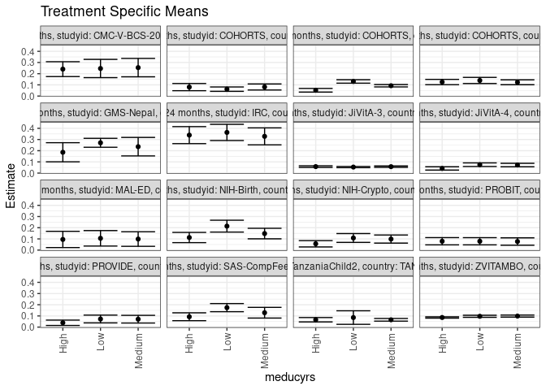

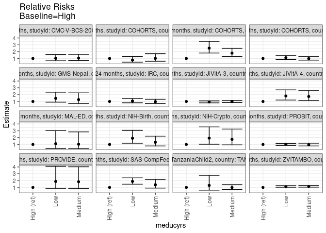

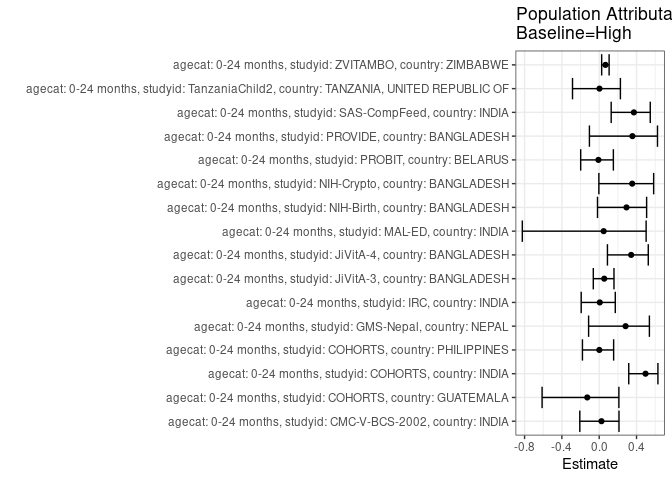

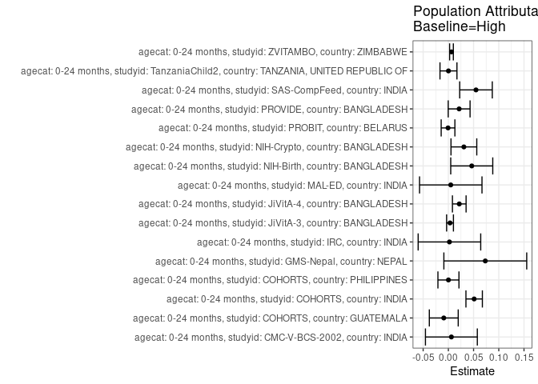

## Results Table

### Parameter: TSM

| agecat | studyid | country | intervention_level | baseline_level | estimate | ci_lower | ci_upper |
| --- | --- | --- | --- | --- | --- | --- | --- |
| 0-24 months | CMC-V-BCS-2002 | INDIA | High | NA | 0.2406642 | 0.1743612 | 0.3069671 |
| 0-24 months | CMC-V-BCS-2002 | INDIA | Low | NA | 0.2463874 | 0.1647644 | 0.3280104 |
| 0-24 months | CMC-V-BCS-2002 | INDIA | Medium | NA | 0.2542556 | 0.1720308 | 0.3364803 |
| 0-24 months | COHORTS | GUATEMALA | High | NA | 0.0802013 | 0.0479978 | 0.1124049 |
| 0-24 months | COHORTS | GUATEMALA | Low | NA | 0.0617142 | 0.0423130 | 0.0811154 |
| 0-24 months | COHORTS | GUATEMALA | Medium | NA | 0.0812173 | 0.0542993 | 0.1081353 |
| 0-24 months | COHORTS | INDIA | High | NA | 0.0518622 | 0.0355043 | 0.0682202 |
| 0-24 months | COHORTS | INDIA | Low | NA | 0.1304605 | 0.1150264 | 0.1458947 |
| 0-24 months | COHORTS | INDIA | Medium | NA | 0.0923411 | 0.0818808 | 0.1028014 |
| 0-24 months | COHORTS | PHILIPPINES | High | NA | 0.1252906 | 0.1016484 | 0.1489329 |
| 0-24 months | COHORTS | PHILIPPINES | Low | NA | 0.1395893 | 0.1120735 | 0.1671052 |
| 0-24 months | COHORTS | PHILIPPINES | Medium | NA | 0.1231863 | 0.1014146 | 0.1449579 |
| 0-24 months | GMS-Nepal | NEPAL | High | NA | 0.1859114 | 0.1004839 | 0.2713390 |
| 0-24 months | GMS-Nepal | NEPAL | Low | NA | 0.2706850 | 0.2307067 | 0.3106632 |
| 0-24 months | GMS-Nepal | NEPAL | Medium | NA | 0.2359626 | 0.1532074 | 0.3187177 |
| 0-24 months | IRC | INDIA | High | NA | 0.3393356 | 0.2633455 | 0.4153257 |
| 0-24 months | IRC | INDIA | Low | NA | 0.3634498 | 0.2909587 | 0.4359409 |
| 0-24 months | IRC | INDIA | Medium | NA | 0.3281652 | 0.2521326 | 0.4041977 |
| 0-24 months | JiVitA-3 | BANGLADESH | High | NA | 0.0577722 | 0.0504490 | 0.0650954 |
| 0-24 months | JiVitA-3 | BANGLADESH | Low | NA | 0.0537205 | 0.0483643 | 0.0590767 |
| 0-24 months | JiVitA-3 | BANGLADESH | Medium | NA | 0.0571937 | 0.0509586 | 0.0634288 |
| 0-24 months | JiVitA-4 | BANGLADESH | High | NA | 0.0414902 | 0.0267546 | 0.0562259 |
| 0-24 months | JiVitA-4 | BANGLADESH | Low | NA | 0.0749186 | 0.0588733 | 0.0909640 |
| 0-24 months | JiVitA-4 | BANGLADESH | Medium | NA | 0.0717694 | 0.0562926 | 0.0872461 |
| 0-24 months | MAL-ED | INDIA | High | NA | 0.0952381 | 0.0225874 | 0.1678888 |
| 0-24 months | MAL-ED | INDIA | Low | NA | 0.1052632 | 0.0361093 | 0.1744170 |
| 0-24 months | MAL-ED | INDIA | Medium | NA | 0.0987654 | 0.0336452 | 0.1638857 |
| 0-24 months | NIH-Birth | BANGLADESH | High | NA | 0.1122813 | 0.0665572 | 0.1580055 |
| 0-24 months | NIH-Birth | BANGLADESH | Low | NA | 0.2140907 | 0.1610521 | 0.2671293 |
| 0-24 months | NIH-Birth | BANGLADESH | Medium | NA | 0.1478535 | 0.1007865 | 0.1949205 |
| 0-24 months | NIH-Crypto | BANGLADESH | High | NA | 0.0563007 | 0.0280334 | 0.0845680 |
| 0-24 months | NIH-Crypto | BANGLADESH | Low | NA | 0.1081944 | 0.0687624 | 0.1476264 |
| 0-24 months | NIH-Crypto | BANGLADESH | Medium | NA | 0.0986559 | 0.0624385 | 0.1348733 |
| 0-24 months | PROBIT | BELARUS | High | NA | 0.0790664 | 0.0465911 | 0.1115417 |
| 0-24 months | PROBIT | BELARUS | Low | NA | 0.0789420 | 0.0466473 | 0.1112367 |
| 0-24 months | PROBIT | BELARUS | Medium | NA | 0.0765151 | 0.0435330 | 0.1094973 |
| 0-24 months | PROVIDE | BANGLADESH | High | NA | 0.0386423 | 0.0147140 | 0.0625707 |
| 0-24 months | PROVIDE | BANGLADESH | Low | NA | 0.0723629 | 0.0376599 | 0.1070660 |
| 0-24 months | PROVIDE | BANGLADESH | Medium | NA | 0.0708127 | 0.0363628 | 0.1052626 |
| 0-24 months | SAS-CompFeed | INDIA | High | NA | 0.0926022 | 0.0574760 | 0.1277284 |
| 0-24 months | SAS-CompFeed | INDIA | Low | NA | 0.1740260 | 0.1377939 | 0.2102581 |
| 0-24 months | SAS-CompFeed | INDIA | Medium | NA | 0.1285982 | 0.0807221 | 0.1764743 |
| 0-24 months | TanzaniaChild2 | TANZANIA, UNITED REPUBLIC OF | High | NA | 0.0660225 | 0.0464878 | 0.0855573 |
| 0-24 months | TanzaniaChild2 | TANZANIA, UNITED REPUBLIC OF | Low | NA | 0.0853659 | 0.0248738 | 0.1458579 |
| 0-24 months | TanzaniaChild2 | TANZANIA, UNITED REPUBLIC OF | Medium | NA | 0.0653595 | 0.0535488 | 0.0771701 |
| 0-24 months | ZVITAMBO | ZIMBABWE | High | NA | 0.0860896 | 0.0802667 | 0.0919126 |
| 0-24 months | ZVITAMBO | ZIMBABWE | Low | NA | 0.0968046 | 0.0876113 | 0.1059979 |
| 0-24 months | ZVITAMBO | ZIMBABWE | Medium | NA | 0.0985842 | 0.0895735 | 0.1075948 |

### Parameter: E(Y)

| agecat | studyid | country | intervention_level | baseline_level | estimate | ci_lower | ci_upper |
| --- | --- | --- | --- | --- | --- | --- | --- |
| 0-24 months | CMC-V-BCS-2002 | INDIA | NA | NA | 0.2466488 | 0.2028447 | 0.2904529 |
| 0-24 months | COHORTS | GUATEMALA | NA | NA | 0.0711044 | 0.0572455 | 0.0849633 |
| 0-24 months | COHORTS | INDIA | NA | NA | 0.1030116 | 0.0952175 | 0.1108057 |
| 0-24 months | COHORTS | PHILIPPINES | NA | NA | 0.1254516 | 0.1136848 | 0.1372183 |
| 0-24 months | GMS-Nepal | NEPAL | NA | NA | 0.2591508 | 0.2262659 | 0.2920358 |
| 0-24 months | IRC | INDIA | NA | NA | 0.3414634 | 0.2955068 | 0.3874201 |
| 0-24 months | JiVitA-3 | BANGLADESH | NA | NA | 0.0610653 | 0.0575838 | 0.0645468 |
| 0-24 months | JiVitA-4 | BANGLADESH | NA | NA | 0.0630996 | 0.0561390 | 0.0700602 |
| 0-24 months | MAL-ED | INDIA | NA | NA | 0.1000000 | 0.0602674 | 0.1397326 |
| 0-24 months | NIH-Birth | BANGLADESH | NA | NA | 0.1586538 | 0.1299648 | 0.1873429 |
| 0-24 months | NIH-Crypto | BANGLADESH | NA | NA | 0.0870712 | 0.0669870 | 0.1071555 |
| 0-24 months | PROBIT | BELARUS | NA | NA | 0.0784116 | 0.0458146 | 0.1110087 |
| 0-24 months | PROVIDE | BANGLADESH | NA | NA | 0.0600000 | 0.0423945 | 0.0776055 |
| 0-24 months | SAS-CompFeed | INDIA | NA | NA | 0.1473893 | 0.1184132 | 0.1763654 |
| 0-24 months | TanzaniaChild2 | TANZANIA, UNITED REPUBLIC OF | NA | NA | 0.0662196 | 0.0562399 | 0.0761994 |
| 0-24 months | ZVITAMBO | ZIMBABWE | NA | NA | 0.0922734 | 0.0874665 | 0.0970804 |

### Parameter: RR

| agecat | studyid | country | intervention_level | baseline_level | estimate | ci_lower | ci_upper |
| --- | --- | --- | --- | --- | --- | --- | --- |
| 0-24 months | CMC-V-BCS-2002 | INDIA | High | High | 1.0000000 | 1.0000000 | 1.000000 |
| 0-24 months | CMC-V-BCS-2002 | INDIA | Low | High | 1.0237809 | 0.6653392 | 1.575328 |
| 0-24 months | CMC-V-BCS-2002 | INDIA | Medium | High | 1.0564746 | 0.6933891 | 1.609686 |
| 0-24 months | COHORTS | GUATEMALA | High | High | 1.0000000 | 1.0000000 | 1.000000 |
| 0-24 months | COHORTS | GUATEMALA | Low | High | 0.7694907 | 0.4625401 | 1.280140 |
| 0-24 months | COHORTS | GUATEMALA | Medium | High | 1.0126675 | 0.6020928 | 1.703218 |
| 0-24 months | COHORTS | INDIA | High | High | 1.0000000 | 1.0000000 | 1.000000 |
| 0-24 months | COHORTS | INDIA | Low | High | 2.5155210 | 1.7957413 | 3.523807 |
| 0-24 months | COHORTS | INDIA | Medium | High | 1.7805083 | 1.2734134 | 2.489537 |
| 0-24 months | COHORTS | PHILIPPINES | High | High | 1.0000000 | 1.0000000 | 1.000000 |
| 0-24 months | COHORTS | PHILIPPINES | Low | High | 1.1141244 | 0.8523794 | 1.456245 |
| 0-24 months | COHORTS | PHILIPPINES | Medium | High | 0.9832042 | 0.7643285 | 1.264758 |
| 0-24 months | GMS-Nepal | NEPAL | High | High | 1.0000000 | 1.0000000 | 1.000000 |
| 0-24 months | GMS-Nepal | NEPAL | Low | High | 1.4559886 | 0.8983016 | 2.359901 |
| 0-24 months | GMS-Nepal | NEPAL | Medium | High | 1.2692202 | 0.7121590 | 2.262023 |
| 0-24 months | IRC | INDIA | High | High | 1.0000000 | 1.0000000 | 1.000000 |
| 0-24 months | IRC | INDIA | Low | High | 1.0710629 | 0.8033627 | 1.427968 |
| 0-24 months | IRC | INDIA | Medium | High | 0.9670814 | 0.7076643 | 1.321596 |
| 0-24 months | JiVitA-3 | BANGLADESH | High | High | 1.0000000 | 1.0000000 | 1.000000 |
| 0-24 months | JiVitA-3 | BANGLADESH | Low | High | 0.9298680 | 0.7947175 | 1.088002 |
| 0-24 months | JiVitA-3 | BANGLADESH | Medium | High | 0.9899863 | 0.8418557 | 1.164181 |
| 0-24 months | JiVitA-4 | BANGLADESH | High | High | 1.0000000 | 1.0000000 | 1.000000 |
| 0-24 months | JiVitA-4 | BANGLADESH | Low | High | 1.8056940 | 1.2086421 | 2.697681 |
| 0-24 months | JiVitA-4 | BANGLADESH | Medium | High | 1.7297906 | 1.1370242 | 2.631585 |
| 0-24 months | MAL-ED | INDIA | High | High | 1.0000000 | 1.0000000 | 1.000000 |
| 0-24 months | MAL-ED | INDIA | Low | High | 1.1052632 | 0.4038751 | 3.024714 |
| 0-24 months | MAL-ED | INDIA | Medium | High | 1.0370370 | 0.3783556 | 2.842421 |
| 0-24 months | NIH-Birth | BANGLADESH | High | High | 1.0000000 | 1.0000000 | 1.000000 |
| 0-24 months | NIH-Birth | BANGLADESH | Low | High | 1.9067341 | 1.1831868 | 3.072748 |
| 0-24 months | NIH-Birth | BANGLADESH | Medium | High | 1.3168123 | 0.7844379 | 2.210493 |
| 0-24 months | NIH-Crypto | BANGLADESH | High | High | 1.0000000 | 1.0000000 | 1.000000 |
| 0-24 months | NIH-Crypto | BANGLADESH | Low | High | 1.9217234 | 1.0334549 | 3.573471 |
| 0-24 months | NIH-Crypto | BANGLADESH | Medium | High | 1.7523036 | 0.9405264 | 3.264733 |
| 0-24 months | PROBIT | BELARUS | High | High | 1.0000000 | 1.0000000 | 1.000000 |
| 0-24 months | PROBIT | BELARUS | Low | High | 0.9984261 | 0.8560484 | 1.164484 |
| 0-24 months | PROBIT | BELARUS | Medium | High | 0.9677325 | 0.7881291 | 1.188265 |
| 0-24 months | PROVIDE | BANGLADESH | High | High | 1.0000000 | 1.0000000 | 1.000000 |
| 0-24 months | PROVIDE | BANGLADESH | Low | High | 1.8726337 | 0.8553686 | 4.099703 |
| 0-24 months | PROVIDE | BANGLADESH | Medium | High | 1.8325156 | 0.8333826 | 4.029498 |
| 0-24 months | SAS-CompFeed | INDIA | High | High | 1.0000000 | 1.0000000 | 1.000000 |
| 0-24 months | SAS-CompFeed | INDIA | Low | High | 1.8792853 | 1.4688455 | 2.404414 |
| 0-24 months | SAS-CompFeed | INDIA | Medium | High | 1.3887163 | 0.8954710 | 2.153652 |
| 0-24 months | TanzaniaChild2 | TANZANIA, UNITED REPUBLIC OF | High | High | 1.0000000 | 1.0000000 | 1.000000 |
| 0-24 months | TanzaniaChild2 | TANZANIA, UNITED REPUBLIC OF | Low | High | 1.2929804 | 0.5999184 | 2.786709 |
| 0-24 months | TanzaniaChild2 | TANZANIA, UNITED REPUBLIC OF | Medium | High | 0.9899570 | 0.6999193 | 1.400183 |
| 0-24 months | ZVITAMBO | ZIMBABWE | High | High | 1.0000000 | 1.0000000 | 1.000000 |
| 0-24 months | ZVITAMBO | ZIMBABWE | Low | High | 1.1244627 | 1.0143801 | 1.246492 |
| 0-24 months | ZVITAMBO | ZIMBABWE | Medium | High | 1.1451338 | 1.0358128 | 1.265993 |

### Parameter: PAR

| agecat | studyid | country | intervention_level | baseline_level | estimate | ci_lower | ci_upper |
| --- | --- | --- | --- | --- | --- | --- | --- |
| 0-24 months | CMC-V-BCS-2002 | INDIA | High | NA | 0.0059846 | -0.0454540 | 0.0574233 |
| 0-24 months | COHORTS | GUATEMALA | High | NA | -0.0090970 | -0.0377449 | 0.0195510 |
| 0-24 months | COHORTS | INDIA | High | NA | 0.0511494 | 0.0348512 | 0.0674476 |
| 0-24 months | COHORTS | PHILIPPINES | High | NA | 0.0001609 | -0.0207076 | 0.0210295 |
| 0-24 months | GMS-Nepal | NEPAL | High | NA | 0.0732394 | -0.0089250 | 0.1554037 |
| 0-24 months | IRC | INDIA | High | NA | 0.0021278 | -0.0599003 | 0.0641559 |
| 0-24 months | JiVitA-3 | BANGLADESH | High | NA | 0.0032931 | -0.0034716 | 0.0100577 |
| 0-24 months | JiVitA-4 | BANGLADESH | High | NA | 0.0216094 | 0.0080715 | 0.0351473 |
| 0-24 months | MAL-ED | INDIA | High | NA | 0.0047619 | -0.0571564 | 0.0666802 |
| 0-24 months | NIH-Birth | BANGLADESH | High | NA | 0.0463725 | 0.0047061 | 0.0880389 |
| 0-24 months | NIH-Crypto | BANGLADESH | High | NA | 0.0307705 | 0.0052064 | 0.0563347 |
| 0-24 months | PROBIT | BELARUS | High | NA | -0.0006548 | -0.0142559 | 0.0129464 |
| 0-24 months | PROVIDE | BANGLADESH | High | NA | 0.0213577 | -0.0003084 | 0.0430238 |
| 0-24 months | SAS-CompFeed | INDIA | High | NA | 0.0547871 | 0.0224632 | 0.0871109 |
| 0-24 months | TanzaniaChild2 | TANZANIA, UNITED REPUBLIC OF | High | NA | 0.0001971 | -0.0166125 | 0.0170066 |
| 0-24 months | ZVITAMBO | ZIMBABWE | High | NA | 0.0061838 | 0.0024934 | 0.0098742 |

### Parameter: PAF

| agecat | studyid | country | intervention_level | baseline_level | estimate | ci_lower | ci_upper |
| --- | --- | --- | --- | --- | --- | --- | --- |
| 0-24 months | CMC-V-BCS-2002 | INDIA | High | NA | 0.0242638 | -0.2081057 | 0.2119389 |
| 0-24 months | COHORTS | GUATEMALA | High | NA | -0.1279381 | -0.6121997 | 0.2108643 |
| 0-24 months | COHORTS | INDIA | High | NA | 0.4965401 | 0.3164920 | 0.6291603 |
| 0-24 months | COHORTS | PHILIPPINES | High | NA | 0.0012828 | -0.1797160 | 0.1545118 |
| 0-24 months | GMS-Nepal | NEPAL | High | NA | 0.2826129 | -0.1137046 | 0.5378988 |
| 0-24 months | IRC | INDIA | High | NA | 0.0062314 | -0.1930541 | 0.1722287 |
| 0-24 months | JiVitA-3 | BANGLADESH | High | NA | 0.0539271 | -0.0633322 | 0.1582555 |
| 0-24 months | JiVitA-4 | BANGLADESH | High | NA | 0.3424649 | 0.0882180 | 0.5258161 |
| 0-24 months | MAL-ED | INDIA | High | NA | 0.0476190 | -0.8241477 | 0.5027653 |
| 0-24 months | NIH-Birth | BANGLADESH | High | NA | 0.2922873 | -0.0183504 | 0.5081681 |
| 0-24 months | NIH-Crypto | BANGLADESH | High | NA | 0.3533951 | -0.0036669 | 0.5834296 |
| 0-24 months | PROBIT | BELARUS | High | NA | -0.0083504 | -0.1985582 | 0.1516719 |
| 0-24 months | PROVIDE | BANGLADESH | High | NA | 0.3559611 | -0.1049371 | 0.6246066 |
| 0-24 months | SAS-CompFeed | INDIA | High | NA | 0.3717168 | 0.1283742 | 0.5471224 |
| 0-24 months | TanzaniaChild2 | TANZANIA, UNITED REPUBLIC OF | High | NA | 0.0029760 | -0.2861107 | 0.2270830 |
| 0-24 months | ZVITAMBO | ZIMBABWE | High | NA | 0.0670160 | 0.0262829 | 0.1060451 |